# Figure 3: enhancer marks in KOs

This script will create the panels of Figure 3 of the manuscript using the EM and Louvain clusters which were identified during the paper revision process.

Defining source

```r
source("cluster_analysis_functions.R")
```

Importing data

```r
read_tsv("../data/interaction_pairs_uncapped.txt") -> magic_table_uncapped
```

## Marks at active enhancers

### EM clusters

#### Figure 3a

Filtering the magic table for relevant values and calculating KO to WT difference

```r
magic_table_uncapped %>%
  filter(EM_cluster_group == "active P - active E") %>%
  select(interaction_ID, contains("EpiLC_D2"), -starts_with("P_"), -starts_with("CHiC"), -contains("mC_"), -contains("ATAC"),
         -contains("CTCF"), -contains("H3K27me3"), -contains("H3K4me3"), -contains("Input")) %>%
  pivot_longer(2:last_col(), names_to = "sample", values_to = "RPKM") %>%
  mutate(sample = gsub("RNA", "PIR_RNA", sample)) %>%
  separate(sample, into = c("fragment", "mark", "line", "genotype", "stage", "day")) %>%
  select(-fragment, -stage, -day) %>%
  pivot_wider(names_from = genotype, values_from = RPKM) %>%
  mutate(KO_WT_diff = KO - WT)-> enhancer_marks_EM

head(enhancer_marks_EM)
```

| interaction_ID | mark | line | KO | WT | KO_WT_diff |
| --- | --- | --- | --- | --- | --- |
| 1_4879113_4882952...1_4969970_4971074 | H3K27ac | DNMT | 6.532677 | 7.233771 | -0.7010942 |
| 1_4879113_4882952...1_4969970_4971074 | H3K27ac | TET | 4.205954 | 10.086244 | -5.8802896 |
| 1_4879113_4882952...1_4969970_4971074 | H3K4me1 | DNMT | 3.362634 | 4.361812 | -0.9991784 |
| 1_4879113_4882952...1_4969970_4971074 | H3K4me1 | TET | 4.805119 | 6.254065 | -1.4489460 |
| 1_4879113_4882952...1_4969970_4971074 | RNA | DNMT | NA | NA | NA |
| 1_4879113_4882952...1_4969970_4971074 | RNA | TET | NA | NA | NA |

Plotting Figure 3a (EM clusters)

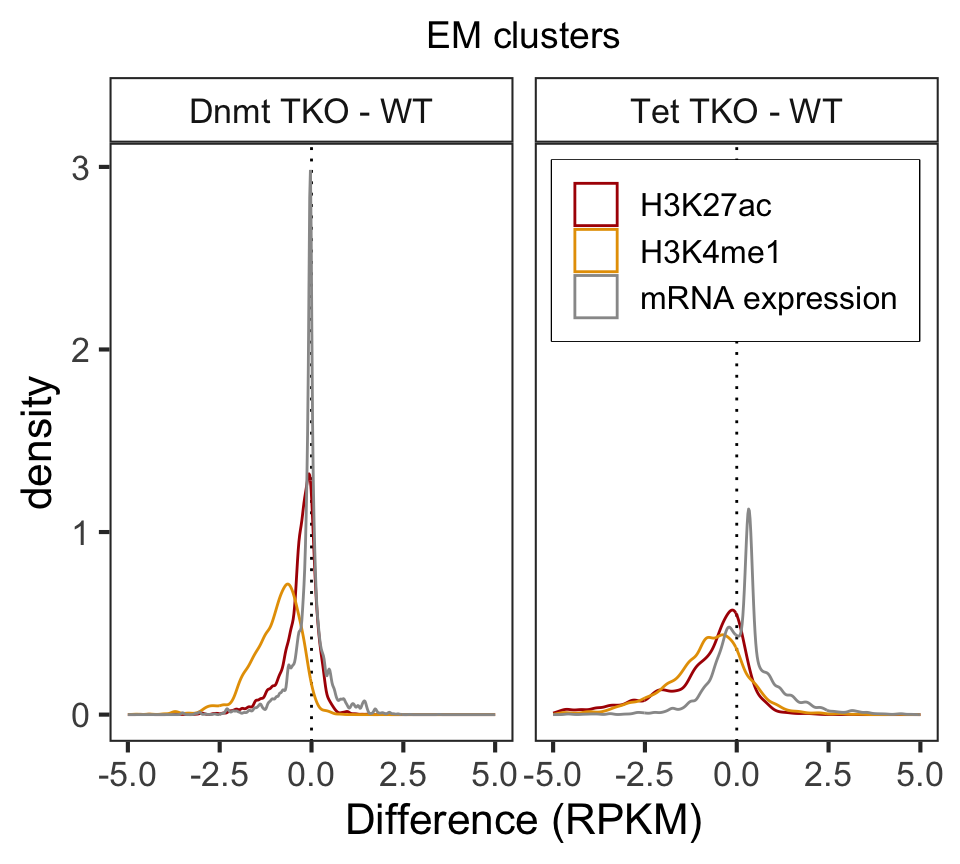

```r
enhancer_marks_EM %>%
  mutate(line = gsub("DNMT", "Dnmt TKO - WT", line)) %>%
  mutate(line = gsub("TET", "Tet TKO - WT", line)) %>%
  mutate(mark = gsub("RNA", "mRNA expression", mark)) %>%
  ggplot(aes(KO_WT_diff, colour = mark)) +
  geom_vline(xintercept = 0, linetype = "dotted") +
  geom_density() +
  xlim(-5, 5) +
  scale_colour_manual(values = c(K27ac_colour, K4me1_colour, exp_colour)) +
  xlab("Difference (RPKM)") +
  ggtitle("EM clusters") +
  facet_wrap(facets = "line") +
  theme(legend.title = element_blank(), strip.background = element_rect(fill = "white"), legend.position = "inside",
        legend.position.inside = c(0.755, 0.82), legend.text = element_text(size = 12), legend.box.background = element_rect(colour = "black"),
        panel.grid = element_blank(), plot.title = element_text(size = 14, hjust = 0.5)) -> figure3a_EM

figure3a_EM
```

### Louvain clusters

#### Figure 3a

Filtering the magic table for relevant values and calculating KO to WT difference

```r
magic_table_uncapped %>%
  filter(Louvain_cluster_group == "active P - active E") %>%
  select(interaction_ID, contains("EpiLC_D2"), -starts_with("P_"), -starts_with("CHiC"), -contains("mC_"), -contains("ATAC"),
         -contains("CTCF"), -contains("H3K27me3"), -contains("H3K4me3"), -contains("Input")) %>%
  pivot_longer(2:last_col(), names_to = "sample", values_to = "RPKM") %>%
  mutate(sample = gsub("RNA", "PIR_RNA", sample)) %>%
  separate(sample, into = c("fragment", "mark", "line", "genotype", "stage", "day")) %>%
  select(-fragment, -stage, -day) %>%
  pivot_wider(names_from = genotype, values_from = RPKM) %>%
  mutate(KO_WT_diff = KO - WT)-> enhancer_marks_Louvain

head(enhancer_marks_Louvain)
```

| interaction_ID | mark | line | KO | WT | KO_WT_diff |
| --- | --- | --- | --- | --- | --- |
| 1_4879113_4882952...1_4969970_4971074 | H3K27ac | DNMT | 6.532677 | 7.233771 | -0.7010942 |
| 1_4879113_4882952...1_4969970_4971074 | H3K27ac | TET | 4.205954 | 10.086244 | -5.8802896 |
| 1_4879113_4882952...1_4969970_4971074 | H3K4me1 | DNMT | 3.362634 | 4.361812 | -0.9991784 |
| 1_4879113_4882952...1_4969970_4971074 | H3K4me1 | TET | 4.805119 | 6.254065 | -1.4489460 |
| 1_4879113_4882952...1_4969970_4971074 | RNA | DNMT | NA | NA | NA |
| 1_4879113_4882952...1_4969970_4971074 | RNA | TET | NA | NA | NA |

Plotting Figure 3a (Louvain clusters)

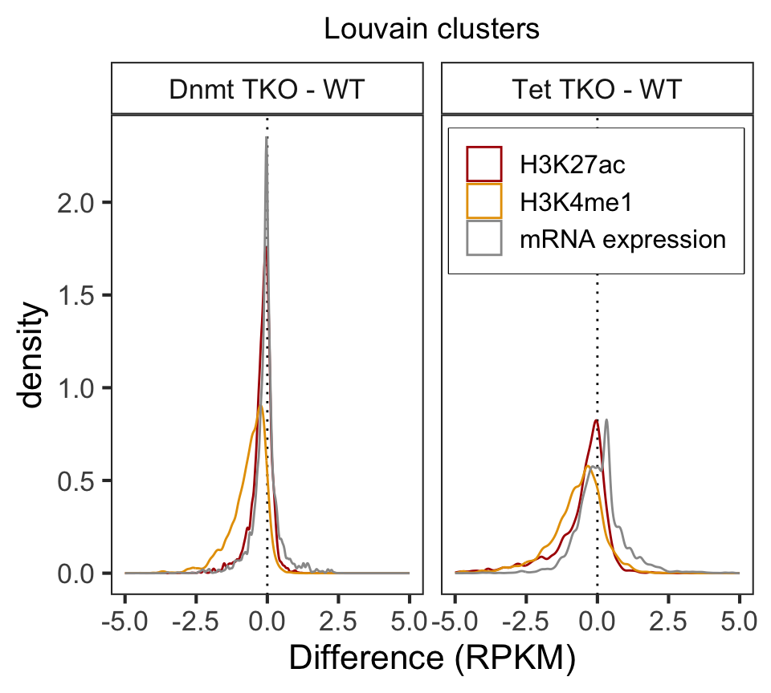

```r
enhancer_marks_Louvain %>%
  mutate(line = gsub("DNMT", "Dnmt TKO - WT", line)) %>%
  mutate(line = gsub("TET", "Tet TKO - WT", line)) %>%
  mutate(mark = gsub("RNA", "mRNA expression", mark)) %>%
  ggplot(aes(KO_WT_diff, colour = mark)) +
  geom_vline(xintercept = 0, linetype = "dotted") +
  geom_density() +
  xlim(-5, 5) +
  scale_colour_manual(values = c(K27ac_colour, K4me1_colour, exp_colour)) +
  xlab("Difference (RPKM)") +
  ggtitle("Louvain clusters") +
  facet_wrap(facets = "line") +
  theme(legend.title = element_blank(), strip.background = element_rect(fill = "white"), legend.position = "inside",
        legend.position.inside = c(0.755, 0.82), legend.text = element_text(size = 12), legend.box.background = element_rect(colour = "black"),
        panel.grid = element_blank(), plot.title = element_text(size = 14, hjust = 0.5)) -> figure3a_Louvain

figure3a_Louvain
```

Exporting plots

```r
ggsave("../output/plots/Figure3a_EM.svg",  figure3a_EM, width = 5, height = 4.5, units = "in")
ggsave("../output/plots/Figure3a_EM.png",  figure3a_EM, width = 5, height = 4.5, units = "in")
ggsave("../output/plots/Figure3a_Louvain.svg",  figure3a_Louvain, width = 5, height = 4.5, units = "in")
ggsave("../output/plots/Figure3a_Louvain.png",  figure3a_Louvain, width = 5, height = 4.5, units = "in")
```

Moving on to Figure 3c

## H3K4me1 marks at promoter - enhancer pairs

### EM clusters

### primed, active and poised enhancers

Filtering the magic table for these categories

```r
magic_table_uncapped %>%
  filter(EM_cluster_group == "inactive P - primed E" | EM_cluster_group == "active P - active E" | EM_cluster_group == "bivalent P - poised E") %>%
  select(interaction_ID, EM_cluster_group, contains("H3K4me1")) %>%
  select(interaction_ID, EM_cluster_group, contains("EpiLC_D2")) %>%
  pivot_longer(3:last_col(), names_to = "sample", values_to = "RPKM") %>%
  separate(sample, into = c("fragment", "mark", "line", "genotype", "stage", "day")) %>%
  select(-mark, -stage, -day) -> K4me1_enhancers_EM

head(K4me1_enhancers_EM)
```

| interaction_ID | EM_cluster_group | fragment | line | genotype | RPKM |
| --- | --- | --- | --- | --- | --- |
| 1_3100832_3102475...1_88257753_88261254 | inactive P - primed E | P | DNMT | KO | 0.3472018 |
| 1_3100832_3102475...1_88257753_88261254 | inactive P - primed E | P | DNMT | WT | 0.1675379 |
| 1_3100832_3102475...1_88257753_88261254 | inactive P - primed E | P | TET | KO | 0.1971367 |
| 1_3100832_3102475...1_88257753_88261254 | inactive P - primed E | P | TET | WT | 0.1846607 |
| 1_3100832_3102475...1_88257753_88261254 | inactive P - primed E | PIR | DNMT | KO | 0.0000000 |
| 1_3100832_3102475...1_88257753_88261254 | inactive P - primed E | PIR | DNMT | WT | 0.0000000 |

Plotting H3K4me1 for enhancer types - EM clusters

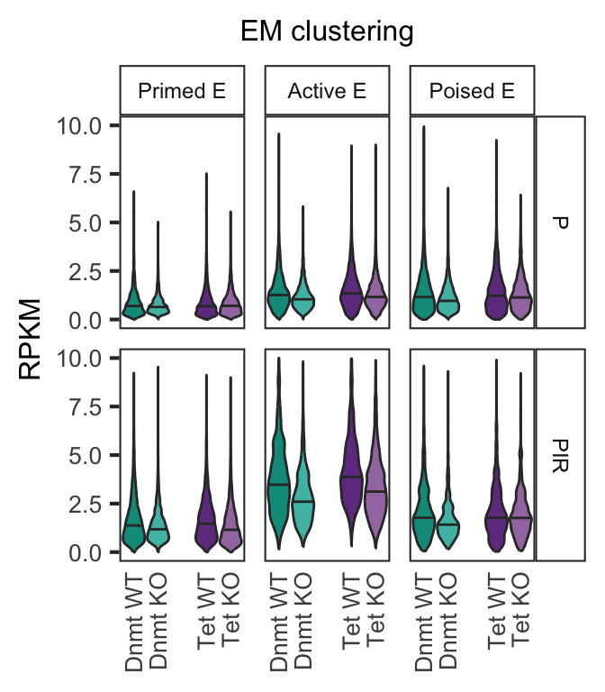

```r
K4me1_enhancers_EM %>%
  mutate(EM_cluster_group = case_when(EM_cluster_group == "inactive P - primed E" ~ "Primed E",
                                      EM_cluster_group == "active P - active E" ~ "Active E",
                                      EM_cluster_group == "bivalent P - poised E" ~ "Poised E")) %>%
  mutate(line = case_when(line == "DNMT" ~ "Dnmt",
                          line == "TET" ~ "Tet")) %>%
  mutate(genotype = factor(genotype, levels = c("WT", "KO"))) %>%
  mutate(EM_cluster_group = factor(EM_cluster_group, levels = c("Primed E", "Active E", "Poised E"))) %>%
  unite(line, genotype, col = "condition", sep = " ") %>%
  mutate(condition = factor(condition, levels = c("Dnmt WT", "Dnmt KO", "", "Tet WT", "Tet KO"))) %>%
  ggplot(aes(condition, RPKM, fill = condition)) +
  ylim(0,10) +
  geom_violin(draw_quantiles = 0.5, scale = "width") +
  ggtitle("EM clustering") +
  scale_fill_manual(values = c(DNMT_Epi_WT_colour, DNMT_Epi_KO_colour, TET_Epi_WT_colour, TET_Epi_KO_colour)) +
  scale_x_discrete(drop=FALSE) +
  facet_grid(fragment ~ EM_cluster_group) +
  theme(legend.position = "none", axis.title.x = element_blank(), axis.text.x = element_text(angle = 90, vjust = 0.5, hjust = 1, size = 10, margin = margin(r=0)),
        panel.grid = element_blank(), strip.background = element_rect(fill = "white"), axis.ticks.x = element_blank(), strip.text = element_text(size = 9),
        axis.title.y = element_text(size = 12), axis.text.y = element_text(size = 10), plot.title = element_text(size = 12, hjust = 0.5)) -> K4me1_enhancer_violins_EM

K4me1_enhancer_violins_EM
```

### Louvain clusters

### primed, active and poised enhancers

Filtering the magic table for these categories

```r
magic_table_uncapped %>%
  filter(Louvain_cluster_group == "inactive P - primed E" | Louvain_cluster_group == "active P - active E" | Louvain_cluster_group == "bivalent P - poised E") %>%
  select(interaction_ID, Louvain_cluster_group, contains("H3K4me1")) %>%
  select(interaction_ID, Louvain_cluster_group, contains("EpiLC_D2")) %>%
  pivot_longer(3:last_col(), names_to = "sample", values_to = "RPKM") %>%
  separate(sample, into = c("fragment", "mark", "line", "genotype", "stage", "day")) %>%
  select(-mark, -stage, -day) -> K4me1_enhancers_Louvain

head(K4me1_enhancers_Louvain)
```

| interaction_ID | Louvain_cluster_group | fragment | line | genotype | RPKM |
| --- | --- | --- | --- | --- | --- |
| 1_4521936_4530090...1_4722492_4723502 | inactive P - primed E | P | DNMT | KO | 0.2970755 |
| 1_4521936_4530090...1_4722492_4723502 | inactive P - primed E | P | DNMT | WT | 0.2212839 |
| 1_4521936_4530090...1_4722492_4723502 | inactive P - primed E | P | TET | KO | 0.2418424 |
| 1_4521936_4530090...1_4722492_4723502 | inactive P - primed E | P | TET | WT | 0.3053441 |
| 1_4521936_4530090...1_4722492_4723502 | inactive P - primed E | PIR | DNMT | KO | 0.5320000 |
| 1_4521936_4530090...1_4722492_4723502 | inactive P - primed E | PIR | DNMT | WT | 0.5034763 |

Plotting H3K4me1 for enhancer types - Louvain clusters

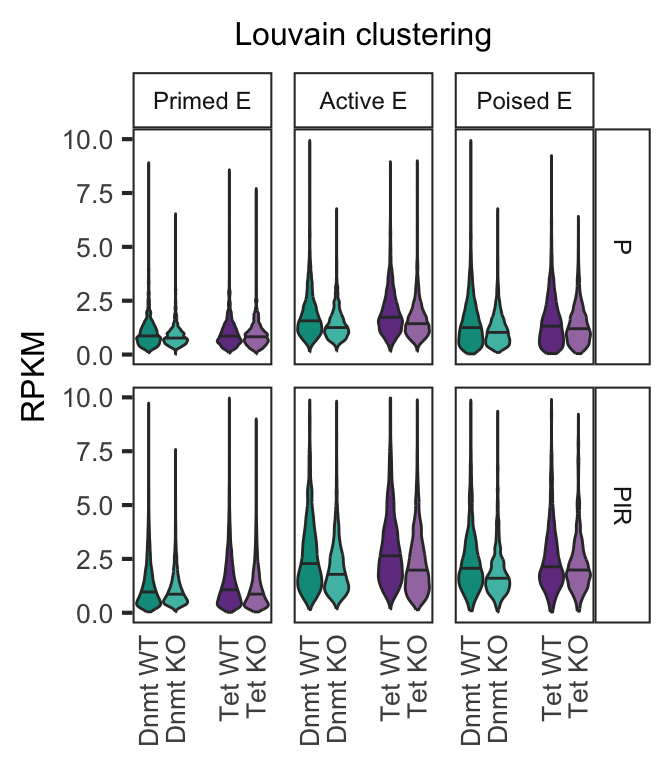

```r
K4me1_enhancers_Louvain %>%
  mutate(Louvain_cluster_group = case_when(Louvain_cluster_group == "inactive P - primed E" ~ "Primed E",
                                      Louvain_cluster_group == "active P - active E" ~ "Active E",
                                      Louvain_cluster_group == "bivalent P - poised E" ~ "Poised E")) %>%
  mutate(line = case_when(line == "DNMT" ~ "Dnmt",
                          line == "TET" ~ "Tet")) %>%
  mutate(genotype = factor(genotype, levels = c("WT", "KO"))) %>%
  mutate(Louvain_cluster_group = factor(Louvain_cluster_group, levels = c("Primed E", "Active E", "Poised E"))) %>%
  unite(line, genotype, col = "condition", sep = " ") %>%
  mutate(condition = factor(condition, levels = c("Dnmt WT", "Dnmt KO", "", "Tet WT", "Tet KO"))) %>%
  ggplot(aes(condition, RPKM, fill = condition)) +
  ylim(0,10) +
  geom_violin(draw_quantiles = 0.5, scale = "width") +
  ggtitle("Louvain clustering") +
  scale_fill_manual(values = c(DNMT_Epi_WT_colour, DNMT_Epi_KO_colour, TET_Epi_WT_colour, TET_Epi_KO_colour)) +
  scale_x_discrete(drop=FALSE) +
  facet_grid(fragment ~ Louvain_cluster_group) +
  theme(legend.position = "none", axis.title.x = element_blank(), axis.text.x = element_text(angle = 90, vjust = 0.5, hjust = 1, size = 10, margin = margin(r=0)),
        panel.grid = element_blank(), strip.background = element_rect(fill = "white"), axis.ticks.x = element_blank(), strip.text = element_text(size = 9),
        axis.title.y = element_text(size = 12), axis.text.y = element_text(size = 10), plot.title = element_text(size = 12, hjust = 0.5)) -> K4me1_enhancer_violins_Louvain

K4me1_enhancer_violins_Louvain
```

Exporting H3K4me1 plots

```r
ggsave("../output/plots/Figure3c_EM.png", K4me1_enhancer_violins_EM, width = 3.5, height = 4, units = "in")
ggsave("../output/plots/Figure3c_EM.svg", K4me1_enhancer_violins_EM, width = 3.5, height = 4, units = "in")
ggsave("../output/plots/Figure3c_Louvain.png", K4me1_enhancer_violins_Louvain, width = 3.5, height = 4, units = "in")
ggsave("../output/plots/Figure3c_Louvain.svg", K4me1_enhancer_violins_Louvain, width = 3.5, height = 4, units = "in")
```

## H3K27ac marks at promoter - enhancer pairs

### EM clusters

### primed, active and poised enhancers

Filtering the magic table for these categories

```r
magic_table_uncapped %>%
  filter(EM_cluster_group == "inactive P - primed E" | EM_cluster_group == "active P - active E" | EM_cluster_group == "bivalent P - poised E") %>%
  select(interaction_ID, EM_cluster_group, contains("H3K27ac")) %>%
  select(interaction_ID, EM_cluster_group, contains("EpiLC_D2")) %>%
  pivot_longer(3:last_col(), names_to = "sample", values_to = "RPKM") %>%
  separate(sample, into = c("fragment", "mark", "line", "genotype", "stage", "day")) %>%
  select(-mark, -stage, -day) -> K27ac_enhancers_EM

head(K27ac_enhancers_EM)
```

| interaction_ID | EM_cluster_group | fragment | line | genotype | RPKM |
| --- | --- | --- | --- | --- | --- |
| 1_3100832_3102475...1_88257753_88261254 | inactive P - primed E | P | DNMT | KO | 0.2767886 |
| 1_3100832_3102475...1_88257753_88261254 | inactive P - primed E | P | DNMT | WT | 0.2597170 |
| 1_3100832_3102475...1_88257753_88261254 | inactive P - primed E | P | TET | KO | 0.2852475 |
| 1_3100832_3102475...1_88257753_88261254 | inactive P - primed E | P | TET | WT | 0.2264807 |
| 1_3100832_3102475...1_88257753_88261254 | inactive P - primed E | PIR | DNMT | KO | 0.0000000 |
| 1_3100832_3102475...1_88257753_88261254 | inactive P - primed E | PIR | DNMT | WT | 0.0000000 |

Plotting H3K27ac for enhancer types - EM clusters

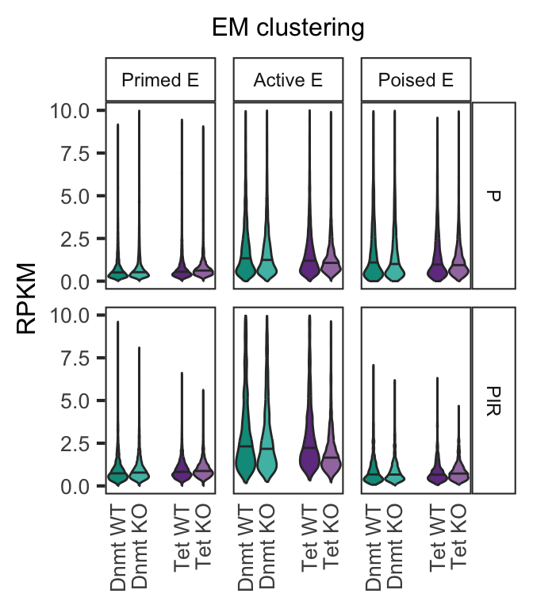

```r
K27ac_enhancers_EM %>%
  mutate(EM_cluster_group = case_when(EM_cluster_group == "inactive P - primed E" ~ "Primed E",
                                      EM_cluster_group == "active P - active E" ~ "Active E",
                                      EM_cluster_group == "bivalent P - poised E" ~ "Poised E")) %>%
  mutate(line = case_when(line == "DNMT" ~ "Dnmt",
                          line == "TET" ~ "Tet")) %>%
  mutate(genotype = factor(genotype, levels = c("WT", "KO"))) %>%
  mutate(EM_cluster_group = factor(EM_cluster_group, levels = c("Primed E", "Active E", "Poised E"))) %>%
  unite(line, genotype, col = "condition", sep = " ") %>%
  mutate(condition = factor(condition, levels = c("Dnmt WT", "Dnmt KO", "", "Tet WT", "Tet KO"))) %>%
  ggplot(aes(condition, RPKM, fill = condition)) +
  ylim(0,10) +
  geom_violin(draw_quantiles = 0.5, scale = "width") +
  ggtitle("EM clustering") +
  scale_fill_manual(values = c(DNMT_Epi_WT_colour, DNMT_Epi_KO_colour, TET_Epi_WT_colour, TET_Epi_KO_colour)) +
  scale_x_discrete(drop=FALSE) +
  facet_grid(fragment ~ EM_cluster_group) +
  theme(legend.position = "none", axis.title.x = element_blank(), axis.text.x = element_text(angle = 90, vjust = 0.5, hjust = 1, size = 10, margin = margin(r=0)),
        panel.grid = element_blank(), strip.background = element_rect(fill = "white"), axis.ticks.x = element_blank(), strip.text = element_text(size = 9),
        axis.title.y = element_text(size = 12), axis.text.y = element_text(size = 10), plot.title = element_text(size = 12, hjust = 0.5)) -> K27ac_enhancer_violins_EM

K27ac_enhancer_violins_EM
```

### Louvain clusters

### primed, active and poised enhancers

Filtering the magic table for these categories

```r
magic_table_uncapped %>%
  filter(Louvain_cluster_group == "inactive P - primed E" | Louvain_cluster_group == "active P - active E" | Louvain_cluster_group == "bivalent P - poised E") %>%
  select(interaction_ID, Louvain_cluster_group, contains("H3K27ac")) %>%
  select(interaction_ID, Louvain_cluster_group, contains("EpiLC_D2")) %>%
  pivot_longer(3:last_col(), names_to = "sample", values_to = "RPKM") %>%
  separate(sample, into = c("fragment", "mark", "line", "genotype", "stage", "day")) %>%
  select(-mark, -stage, -day) -> K27ac_enhancers_Louvain

head(K27ac_enhancers_Louvain)
```

| interaction_ID | Louvain_cluster_group | fragment | line | genotype | RPKM |
| --- | --- | --- | --- | --- | --- |
| 1_4521936_4530090...1_4722492_4723502 | inactive P - primed E | P | DNMT | KO | 0.1813974 |
| 1_4521936_4530090...1_4722492_4723502 | inactive P - primed E | P | DNMT | WT | 0.1500900 |
| 1_4521936_4530090...1_4722492_4723502 | inactive P - primed E | P | TET | KO | 0.2650267 |
| 1_4521936_4530090...1_4722492_4723502 | inactive P - primed E | P | TET | WT | 0.2816720 |
| 1_4521936_4530090...1_4722492_4723502 | inactive P - primed E | PIR | DNMT | KO | 0.4080811 |
| 1_4521936_4530090...1_4722492_4723502 | inactive P - primed E | PIR | DNMT | WT | 0.2916420 |

Plotting H3K27ac for enhancer types - Louvain clusters

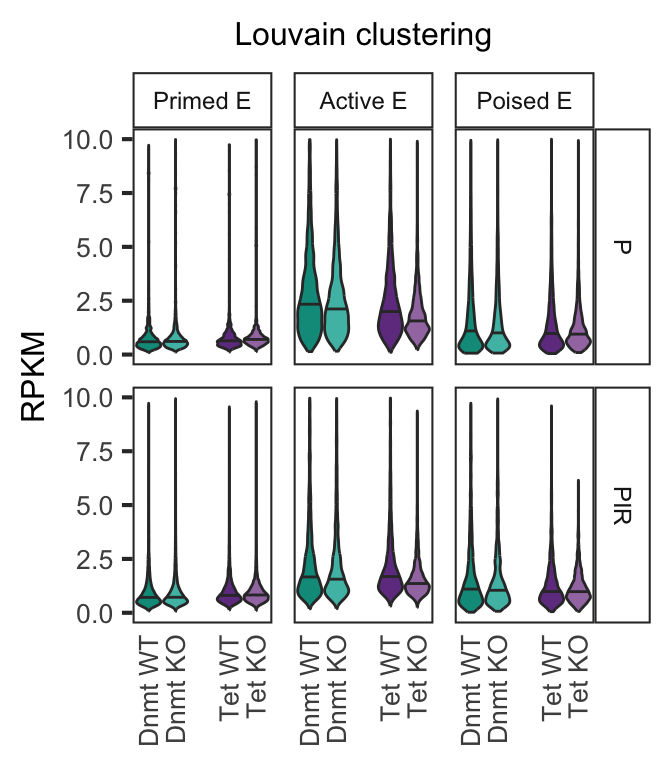

```r
K27ac_enhancers_Louvain %>%
  mutate(Louvain_cluster_group = case_when(Louvain_cluster_group == "inactive P - primed E" ~ "Primed E",
                                      Louvain_cluster_group == "active P - active E" ~ "Active E",
                                      Louvain_cluster_group == "bivalent P - poised E" ~ "Poised E")) %>%
  mutate(line = case_when(line == "DNMT" ~ "Dnmt",
                          line == "TET" ~ "Tet")) %>%
  mutate(genotype = factor(genotype, levels = c("WT", "KO"))) %>%
  mutate(Louvain_cluster_group = factor(Louvain_cluster_group, levels = c("Primed E", "Active E", "Poised E"))) %>%
  unite(line, genotype, col = "condition", sep = " ") %>%
  mutate(condition = factor(condition, levels = c("Dnmt WT", "Dnmt KO", "", "Tet WT", "Tet KO"))) %>%
  ggplot(aes(condition, RPKM, fill = condition)) +
  ylim(0,10) +
  geom_violin(draw_quantiles = 0.5, scale = "width") +
  ggtitle("Louvain clustering") +
  scale_fill_manual(values = c(DNMT_Epi_WT_colour, DNMT_Epi_KO_colour, TET_Epi_WT_colour, TET_Epi_KO_colour)) +
  scale_x_discrete(drop=FALSE) +
  facet_grid(fragment ~ Louvain_cluster_group) +
  theme(legend.position = "none", axis.title.x = element_blank(), axis.text.x = element_text(angle = 90, vjust = 0.5, hjust = 1, size = 10, margin = margin(r=0)),
        panel.grid = element_blank(), strip.background = element_rect(fill = "white"), axis.ticks.x = element_blank(), strip.text = element_text(size = 9),
        axis.title.y = element_text(size = 12), axis.text.y = element_text(size = 10), plot.title = element_text(size = 12, hjust = 0.5)) -> K27ac_enhancer_violins_Louvain

K27ac_enhancer_violins_Louvain
```

Exporting H3K27ac plots

```r
ggsave("../output/plots/Figure3d_EM.png", K27ac_enhancer_violins_EM, width = 3.5, height = 4, units = "in")
ggsave("../output/plots/Figure3d_EM.svg", K27ac_enhancer_violins_EM, width = 3.5, height = 4, units = "in")
ggsave("../output/plots/Figure3d_Louvain.png", K27ac_enhancer_violins_Louvain, width = 3.5, height = 4, units = "in")
ggsave("../output/plots/Figure3d_Louvain.svg", K27ac_enhancer_violins_Louvain, width = 3.5, height = 4, units = "in")
```

## H3K27me3 marks at promoter - PIR pairs

### EM clusters

### polycomb promoters and poised enhancers

Filtering the magic table for these categories

```r
magic_table_uncapped %>%
  filter(EM_cluster_group == "polycomb P - unmarked PIR" | EM_cluster_group == "bivalent P - poised E") %>%
  select(interaction_ID, EM_cluster_group, contains("H3K27me3")) %>%
  select(interaction_ID, EM_cluster_group, contains("EpiLC_D2")) %>%
  pivot_longer(3:last_col(), names_to = "sample", values_to = "RPKM") %>%
  separate(sample, into = c("fragment", "mark", "line", "genotype", "stage", "day")) %>%
  select(-mark, -stage, -day) -> K27me3_enhancers_EM

head(K27me3_enhancers_EM)
```

| interaction_ID | EM_cluster_group | fragment | line | genotype | RPKM |
| --- | --- | --- | --- | --- | --- |
| 1_3669625_3675236...1_4135011_4135938 | polycomb P - unmarked PIR | P | DNMT | KO | 0.7724473 |
| 1_3669625_3675236...1_4135011_4135938 | polycomb P - unmarked PIR | P | DNMT | WT | 0.6813250 |
| 1_3669625_3675236...1_4135011_4135938 | polycomb P - unmarked PIR | P | TET | KO | 2.7862313 |
| 1_3669625_3675236...1_4135011_4135938 | polycomb P - unmarked PIR | P | TET | WT | 2.1069329 |
| 1_3669625_3675236...1_4135011_4135938 | polycomb P - unmarked PIR | PIR | DNMT | KO | 0.5276659 |
| 1_3669625_3675236...1_4135011_4135938 | polycomb P - unmarked PIR | PIR | DNMT | WT | 0.4276471 |

Plotting H3K27me3 for PIR types - EM clusters

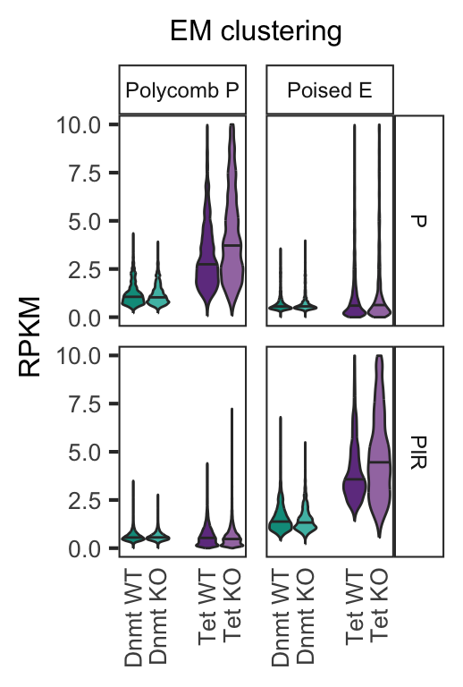

```r
K27me3_enhancers_EM %>%
  mutate(EM_cluster_group = case_when(EM_cluster_group == "polycomb P - unmarked PIR" ~ "Polycomb P",
                                      EM_cluster_group == "bivalent P - poised E" ~ "Poised E")) %>%
  mutate(line = case_when(line == "DNMT" ~ "Dnmt",
                          line == "TET" ~ "Tet")) %>%
  mutate(genotype = factor(genotype, levels = c("WT", "KO"))) %>%
  mutate(EM_cluster_group = factor(EM_cluster_group, levels = c("Polycomb P", "Poised E"))) %>%
  unite(line, genotype, col = "condition", sep = " ") %>%
  mutate(condition = factor(condition, levels = c("Dnmt WT", "Dnmt KO", "", "Tet WT", "Tet KO"))) %>%
  ggplot(aes(condition, RPKM, fill = condition)) +
  ylim(0,10) +
  geom_violin(draw_quantiles = 0.5, scale = "width") +
  ggtitle("EM clustering") +
  scale_fill_manual(values = c(DNMT_Epi_WT_colour, DNMT_Epi_KO_colour, TET_Epi_WT_colour, TET_Epi_KO_colour)) +
  scale_x_discrete(drop=FALSE) +
  facet_grid(fragment ~ EM_cluster_group) +
  theme(legend.position = "none", axis.title.x = element_blank(), axis.text.x = element_text(angle = 90, vjust = 0.5, hjust = 1, size = 10, margin = margin(r=0)),
        panel.grid = element_blank(), strip.background = element_rect(fill = "white"), axis.ticks.x = element_blank(), strip.text = element_text(size = 9),
        axis.title.y = element_text(size = 12), axis.text.y = element_text(size = 10), plot.title = element_text(size = 12, hjust = 0.5)) -> K27me3_enhancer_violins_EM

K27me3_enhancer_violins_EM
```

### Louvain clusters

### polycomb promoters and poised enhancers

Filtering the magic table for these categories

```r
magic_table_uncapped %>%
  filter(Louvain_cluster_group == "polycomb P - unmarked PIR" | Louvain_cluster_group == "bivalent P - poised E") %>%
  select(interaction_ID, Louvain_cluster_group, contains("H3K27me3")) %>%
  select(interaction_ID, Louvain_cluster_group, contains("EpiLC_D2")) %>%
  pivot_longer(3:last_col(), names_to = "sample", values_to = "RPKM") %>%
  separate(sample, into = c("fragment", "mark", "line", "genotype", "stage", "day")) %>%
  select(-mark, -stage, -day) -> K27me3_enhancers_Louvain

head(K27me3_enhancers_Louvain)
```

| interaction_ID | Louvain_cluster_group | fragment | line | genotype | RPKM |
| --- | --- | --- | --- | --- | --- |
| 1_3669625_3675236...1_4135011_4135938 | polycomb P - unmarked PIR | P | DNMT | KO | 0.7724473 |
| 1_3669625_3675236...1_4135011_4135938 | polycomb P - unmarked PIR | P | DNMT | WT | 0.6813250 |
| 1_3669625_3675236...1_4135011_4135938 | polycomb P - unmarked PIR | P | TET | KO | 2.7862313 |
| 1_3669625_3675236...1_4135011_4135938 | polycomb P - unmarked PIR | P | TET | WT | 2.1069329 |
| 1_3669625_3675236...1_4135011_4135938 | polycomb P - unmarked PIR | PIR | DNMT | KO | 0.5276659 |
| 1_3669625_3675236...1_4135011_4135938 | polycomb P - unmarked PIR | PIR | DNMT | WT | 0.4276471 |

Plotting H3K27me3 for PIR types - Louvain clusters

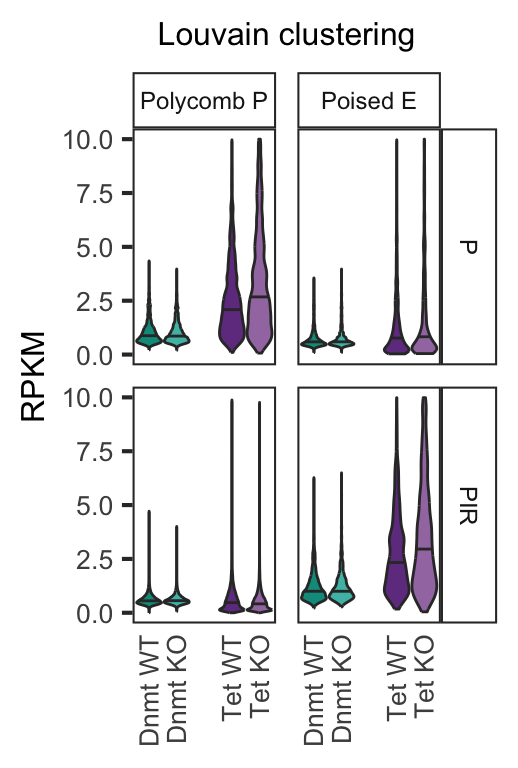

```r
K27me3_enhancers_Louvain %>%
  mutate(Louvain_cluster_group = case_when(Louvain_cluster_group == "polycomb P - unmarked PIR" ~ "Polycomb P",
                                      Louvain_cluster_group == "bivalent P - poised E" ~ "Poised E")) %>%
  mutate(line = case_when(line == "DNMT" ~ "Dnmt",
                          line == "TET" ~ "Tet")) %>%
  mutate(genotype = factor(genotype, levels = c("WT", "KO"))) %>%
  mutate(Louvain_cluster_group = factor(Louvain_cluster_group, levels = c("Polycomb P", "Poised E"))) %>%
  unite(line, genotype, col = "condition", sep = " ") %>%
  mutate(condition = factor(condition, levels = c("Dnmt WT", "Dnmt KO", "", "Tet WT", "Tet KO"))) %>%
  ggplot(aes(condition, RPKM, fill = condition)) +
  ylim(0,10) +
  geom_violin(draw_quantiles = 0.5, scale = "width") +
  ggtitle("Louvain clustering") +
  scale_fill_manual(values = c(DNMT_Epi_WT_colour, DNMT_Epi_KO_colour, TET_Epi_WT_colour, TET_Epi_KO_colour)) +
  scale_x_discrete(drop=FALSE) +
  facet_grid(fragment ~ Louvain_cluster_group) +
  theme(legend.position = "none", axis.title.x = element_blank(), axis.text.x = element_text(angle = 90, vjust = 0.5, hjust = 1, size = 10, margin = margin(r=0)),
        panel.grid = element_blank(), strip.background = element_rect(fill = "white"), axis.ticks.x = element_blank(), strip.text = element_text(size = 9),
        axis.title.y = element_text(size = 12), axis.text.y = element_text(size = 10), plot.title = element_text(size = 12, hjust = 0.5)) -> K27me3_enhancer_violins_Louvain

K27me3_enhancer_violins_Louvain
```

Exporting H3K27me3 plots

```r
ggsave("../output/plots/Figure3e_EM.png", K27me3_enhancer_violins_EM, width = 2.7, height = 4, units = "in")
ggsave("../output/plots/Figure3e_EM.svg", K27me3_enhancer_violins_EM, width = 2.7, height = 4, units = "in")
ggsave("../output/plots/Figure3e_Louvain.png", K27me3_enhancer_violins_Louvain, width = 2.7, height = 4, units = "in")
ggsave("../output/plots/Figure3e_Louvain.svg", K27me3_enhancer_violins_Louvain, width = 2.7, height = 4, units = "in")
```